```python
import pandas as pd
import numpy as np
import seaborn as sns
import matplotlib.pyplot as plt
import re
import warnings
from sklearn.model_selection import train_test_split
from sklearn.pipeline import Pipeline
from sklearn.preprocessing import OneHotEncoder,PowerTransformer
from sklearn.compose import ColumnTransformer
from sklearn.dummy import DummyClassifier
from sklearn.linear_model import LogisticRegression
from sklearn.ensemble import RandomForestClassifier
from sklearn.metrics import accuracy_score, plot_confusion_matrix
from pdpbox import pdp

warnings.filterwarnings('ignore')
```

# Introduction

### 1. Results

The study of the correlation of the predictors with the target variable shows the following correlation:

- Significant correlated categorical feature values: LeanReason (goods), CheckingAccountBalance(none, debt,some), DebtsPaid(paid,delayed), SavingAccountbalance(some,none)
- Siginifcant correlated numerical features: LoanPayoffPeriodInMonths, RequestedAmount, YearsCurrentEmployer

### 3.Improvements

- Model hyper parameter tuning (regularization)
- Model metric to priorize one class's missclassfications
- Correlate missclassification with predictors (cf residuals analysis)
- Refine feature eng/cleaning assumptions
- Add non linearity in logit: polynomial, feature combination

## 0. Data extraction

We full outer join all the datasets by the customID, each data set having only 1 record per customerID

```python
# app
col_names = ['CustomerID','LoanPayoffPeriodInMonths','LoanReason','RequestedAmount','InterestRate','Co-Applicant']
file_path = '/Users/louis/Downloads/Spiny Take Home Challenge/ds-app.tsv'
dt_app = pd.read_csv(file_path,delim_whitespace=True,header=None,names = col_names).set_index('CustomerID')
# credit
col_names = ['CustomerID','CheckingAccountBalance','DebtsPaid','SavingsAccountBalance','CurrentOpenLoanApplications']
file_path = '/Users/louis/Downloads/Spiny Take Home Challenge/ds-credit.tsv'
dt_credit = pd.read_csv(file_path,delim_whitespace=True,header=None,names = col_names).set_index('CustomerID')
# borrower
col_names = ['CustomerID','YearsAtCurrentEmployer','YearsInCurrentResidence','Age','RentOrOwnHome','TypeOfCurrentEmployment','NumberOfDependantsIncludingSelf']
file_path = '/Users/louis/Downloads/Spiny Take Home Challenge/ds-borrower.tsv'
dt_borrower = pd.read_csv(file_path,delim_whitespace=True,header=None,names = col_names).set_index('CustomerID')
# result
col_names = ['CustomerID', 'WasTheLoanApproved']
file_path = '/Users/louis/Downloads/Spiny Take Home Challenge/ds-result.tsv'
dt_result = pd.read_csv(file_path,delim_whitespace=True,header=None,names = col_names).set_index('CustomerID')
# Gather
dt = dt_app.join(dt_credit, how = 'outer').join(dt_borrower, how = 'outer').join(dt_result, how = 'outer')
```

## 1. Pre-Cleaning

We look for:

- Na in the target variable
- nan values encoded incorrectly ('not_available',etc)
- Strange values

### Unexpected Nas

```python
dts = [dt_app,dt_credit,dt_borrower,dt_result]
for d in dts:
    print(d.isna().sum())
```

```
LoanPayoffPeriodInMonths    0
LoanReason                  0
RequestedAmount             0
InterestRate                0
Co-Applicant                5
dtype: int64
CheckingAccountBalance         0
DebtsPaid                      0
SavingsAccountBalance          0
CurrentOpenLoanApplications    0
dtype: int64
YearsAtCurrentEmployer             0
YearsInCurrentResidence            0
Age                                0
RentOrOwnHome                      0
TypeOfCurrentEmployment            0
NumberOfDependantsIncludingSelf    0
dtype: int64
WasTheLoanApproved    0
dtype: int64
```

```python
dt.isna().sum()
```

```
LoanPayoffPeriodInMonths           101
LoanReason                         101
RequestedAmount                    101
InterestRate                       101
Co-Applicant                       106
CheckingAccountBalance             100
DebtsPaid                          100
SavingsAccountBalance              100
CurrentOpenLoanApplications        100
YearsAtCurrentEmployer             100
YearsInCurrentResidence            100
Age                                100
RentOrOwnHome                      100
TypeOfCurrentEmployment            100
NumberOfDependantsIncludingSelf    100
WasTheLoanApproved                  99
dtype: int64
```

> - Seems like there are loan without result
> - Assume it is the test set

```python
dt['testSet'] = dt.WasTheLoanApproved.isna()
dt_train,dt_test = dt[dt.testSet ==False],dt[dt.testSet ==True]
```

```python
nas = dt.isna().sum()
na_cols = nas[nas>0].index.tolist()
```

```python
na_cols.remove('WasTheLoanApproved')
```

```python
for col in dt.select_dtypes(np.object):
    print(col, dt[col].unique())
```

```
LoanPayoffPeriodInMonths [nan '9' '12' '18' '24' '36' '6' '21' '22' '30' '7' '33' '48' '10' '42'
 '15' '4' '39' '11' '14' '60' '54' 'goods' '20' '8' '13' 'busin' '27' '45'
 'none' '28' '16' '40' '5' '26' '47' '72']
LoanReason [nan 'goods' 'auto' 'repairs' 'busin' 'other' 'school']
InterestRate [nan '1' '4' '2' '3' 'none']
Co-Applicant [nan 'none' 'co-app' 'guarant']
CheckingAccountBalance ['debt' 'none' 'high' 'some' nan]
DebtsPaid ['paid' 'delayed' nan]
SavingsAccountBalance ['medium' 'none' 'high' 'some' 'v.high' nan]
YearsAtCurrentEmployer ['7' '4' '10+' nan '1' '0']
RentOrOwnHome ['owned' 'free' nan 'rent']
TypeOfCurrentEmployment ['self' 'skilled' 'unskill' nan 'none']
WasTheLoanApproved ['Y' 'N' '1' nan]
```

> - no hidden Nan in 'none' values

#### Correlated Nan ?

```python
dt_train[dt_train.loc[:,na_cols].isna().any(axis = 1)].loc[:,na_cols].head().T#.all(axis = 1).sum()
```

| CustomerID | 1 | 7 | 9 | 11 | 12 |
| --- | --- | --- | --- | --- | --- |
| LoanPayoffPeriodInMonths | NaN | 12 | 12 | NaN | 18 |
| LoanReason | NaN | auto | goods | NaN | busin |
| RequestedAmount | NaN | 1413 | 585 | NaN | 1887 |
| InterestRate | NaN | 3 | 4 | NaN | 4 |
| Co-Applicant | NaN | none | co-app | NaN | none |
| CheckingAccountBalance | debt | none | some | debt | some |
| DebtsPaid | paid | paid | delayed | paid | delayed |
| SavingsAccountBalance | medium | v.high | some | some | none |
| CurrentOpenLoanApplications | 1 | 1 | 2 | 2 | 2 |
| YearsAtCurrentEmployer | 7 | NaN | NaN | 4 | NaN |
| YearsInCurrentResidence | 3 | NaN | NaN | 2 | NaN |
| Age | 30 | NaN | NaN | 25 | NaN |
| RentOrOwnHome | owned | NaN | NaN | owned | NaN |
| TypeOfCurrentEmployment | self | NaN | NaN | skilled | NaN |
| NumberOfDependantsIncludingSelf | 2 | NaN | NaN | 1 | NaN |

```python
dt_test[dt_test.loc[:,na_cols].isna().any(axis = 1)].loc[:,na_cols].head().T#.all(axis = 1).sum()
```

| CustomerID | 752 | 756 | 757 | 760 | 763 |
| --- | --- | --- | --- | --- | --- |
| LoanPayoffPeriodInMonths | 11 | NaN | 24 | 12 | 24 |
| LoanReason | auto | NaN | auto | auto | auto |
| RequestedAmount | 3939 | NaN | 947 | 3386 | 3757 |
| InterestRate | 1 | NaN | 4 | 3 | 4 |
| Co-Applicant | none | NaN | none | none | co-app |
| CheckingAccountBalance | NaN | debt | NaN | NaN | NaN |
| DebtsPaid | NaN | paid | NaN | NaN | NaN |
| SavingsAccountBalance | NaN | some | NaN | NaN | NaN |
| CurrentOpenLoanApplications | NaN | 1 | NaN | NaN | NaN |
| YearsAtCurrentEmployer | NaN | 4 | 7 | 10+ | 10+ |
| YearsInCurrentResidence | NaN | 2 | 3 | 4 | 4 |
| Age | NaN | 26 | 38 | 35 | 62 |
| RentOrOwnHome | NaN | owned | free | free | free |
| TypeOfCurrentEmployment | NaN | skilled | skilled | skilled | skilled |
| NumberOfDependantsIncludingSelf | NaN | 2 | 2 | 1 | 1 |

```python
dt_test.isna().sum()
```

```
LoanPayoffPeriodInMonths           14
LoanReason                         14
RequestedAmount                    14
InterestRate                       14
Co-Applicant                       14
CheckingAccountBalance             10
DebtsPaid                          10
SavingsAccountBalance              10
CurrentOpenLoanApplications        10
YearsAtCurrentEmployer              9
YearsInCurrentResidence             9
Age                                 9
RentOrOwnHome                       9
TypeOfCurrentEmployment             9
NumberOfDependantsIncludingSelf     9
WasTheLoanApproved                 99
testSet                             0
dtype: int64
```

```python
dt_test.shape
```

```
(99, 17)
```

> - lots of nas (10%) in dt_test >> need to impute them
> - replace with marker for cat columns
> - flag with special value + feature for num features

### Incorrectly encoded Nas

```python
for col in nas[nas>0].index:
    print(col,dt[col].unique())
```

[output not shown]

[output cut: 34 more lines]

```
InterestRate [nan '1' '4' '2' '3' 'none']
Co-Applicant [nan 'none' 'co-app' 'guarant']
CheckingAccountBalance ['debt' 'none' 'high' 'some' nan]
DebtsPaid ['paid' 'delayed' nan]
SavingsAccountBalance ['medium' 'none' 'high' 'some' 'v.high' nan]
CurrentOpenLoanApplications [ 1.  2.  3. nan  4.]
YearsAtCurrentEmployer ['7' '4' '10+' nan '1' '0']
YearsInCurrentResidence [ 3.  2.  4.  1. nan]
Age [30. 33. 28. 51. 25. 44. nan 29. 52. 32. 22. 36. 43. 48. 21. 35. 34. 49.
 46. 26. 27. 31. 40. 47. 39. 41. 74. 45. 57. 50. 23. 66. 37. 38. 24. 67.
 42. 20. 61. 75. 54. 56. 53. 58. 63. 55. 65. 59. 60. 19. 64. 68. 62. 70.]
RentOrOwnHome ['owned' 'free' nan 'rent']
TypeOfCurrentEmployment ['self' 'skilled' 'unskill' nan 'none']
NumberOfDependantsIncludingSelf [ 2.  1. nan]
WasTheLoanApproved ['Y' 'N' '1' nan]
```

- LoanPayoffPeriodInMonths: encode particular values (actually alredy in loanreason) + nas
- LoanReason: regular na marker
- RequestedAmount: num na marker + add columns marker
- InterestRate: add column marker (nas and none)
- Co-Applicant: regular na marker
- CheckingAccountBalance: regular na marker
- DebtsPaid: regular na marker
- SavingsAccountBalance: regular na marker
- CurrentOpenLoanApplications: num na marker + add columns marker
- YearsAtCurrentEmployer: num na marker + add columns marker (with 10+ marker)
- YearsInCurrentResidence: num na marker + add columns marker
- Age: num na marker + add columns marker
- RentOrOwnHome: regular na marker
- TypeOfCurrentEmployment: regular na marker
- NumberOfDependantsIncludingSelf: num na marker + add columns marker
- WasTheLoanApproved: test/train. Whats 1 ?

### Strange Values

```python
# WasTheLoanApproved
dt[dt.WasTheLoanApproved == '1']
```

| CustomerID | LoanPayoffPeriodInMonths | LoanReason | RequestedAmount | InterestRate | Co-Applicant | CheckingAccountBalance | DebtsPaid | SavingsAccountBalance | CurrentOpenLoanApplications | YearsAtCurrentEmployer | YearsInCurrentResidence | Age | RentOrOwnHome | TypeOfCurrentEmployment | NumberOfDependantsIncludingSelf | WasTheLoanApproved | testSet |
| --- | --- | --- | --- | --- | --- | --- | --- | --- | --- | --- | --- | --- | --- | --- | --- | --- | --- |
| 278 | 45 | auto | 4576.0 | 3 | none | some | delayed | medium | 1.0 | 0 | 4.0 | 27.0 | owned | skilled | 1.0 | 1 | False |

> - Replace by 'Y'

```python
dt.WasTheLoanApproved = np.where(dt.WasTheLoanApproved == '1','Y',dt.WasTheLoanApproved)
```

## 2.Nas and feature engineering

### Regular na markers

The following columns are categoricals where we can simply replace the nas by a na marker 'not_available'

- LoanReason
- Co-Applicant
- CheckingAccountBalance:
- DebtsPaid
- SavingsAccountBalance:
- RentOrOwnHome
- TypeOfCurrentEmployment

```python
cols = ['LoanReason','Co-Applicant','CheckingAccountBalance','DebtsPaid','SavingsAccountBalance','RentOrOwnHome','TypeOfCurrentEmployment']
dt[cols] = dt[cols].fillna('not_available')
```

### LoanPayoffPeriodInMonths

There is an obvious ordinal nature which is spoiled by some categorical values. We do the following:

- Replace categorical values 'none','busin' and 'goods' both by 0 as they seem to correspond to no payoff period
- Replace Nas by mean and add a column to flag the nas
- Finally cast the type to int

```python
dt.LoanPayoffPeriodInMonths.unique()
```

```
array([nan, '9', '12', '18', '24', '36', '6', '21', '22', '30', '7', '33',
       '48', '10', '42', '15', '4', '39', '11', '14', '60', '54', 'goods',
       '20', '8', '13', 'busin', '27', '45', 'none', '28', '16', '40',
       '5', '26', '47', '72'], dtype=object)
```

```python
# Dedicated na column
dt['LoanPayoffPeriodInMonths'+'IsNa'] = dt.LoanPayoffPeriodInMonths.isna()
# Replace nas and categorical values
dt.LoanPayoffPeriodInMonths = np.where(dt.LoanPayoffPeriodInMonths.str.contains(pat = '\D').fillna(False),0,dt.LoanPayoffPeriodInMonths)
# Cast type
dt.LoanPayoffPeriodInMonths = dt.LoanPayoffPeriodInMonths.astype(np.float)
dt.LoanPayoffPeriodInMonths.fillna(dt.LoanPayoffPeriodInMonths.mean(),inplace = True)
```

### RequestedAmount

- Idem LoanPayoffPeriod

```python
dt['RequestedAmount'+'IsNa'] = dt.RequestedAmount.isna()
dt.RequestedAmount.fillna(dt.RequestedAmount.mean(),inplace = True)
```

### Interest Rate

- Idem Loan

```python
dt.InterestRate.unique()
```

```
array([nan, '1', '4', '2', '3', 'none'], dtype=object)
```

```python
# Dedicated na columns
dt['InterestRate'+'IsNa'] = dt.InterestRate.isna()
# Replace nones and nas
dt.InterestRate = np.where(dt.InterestRate.str.contains('\D'),0,dt.InterestRate)
dt.InterestRate = dt.InterestRate.astype(np.int)
dt.InterestRate.fillna(dt.InterestRate.mean(),inplace = True)
```

### CurrentOpenLoanApplications

- Same Loan

```python
dt.CurrentOpenLoanApplications.unique()
```

```
array([ 1.,  2.,  3., nan,  4.])
```

```python
# Dedicated na columns
dt['CurrentOpenLoanApplications'+'IsNa'] = dt.CurrentOpenLoanApplications.isna()
# Replace nas
dt.CurrentOpenLoanApplications.fillna(dt.CurrentOpenLoanApplications.mean(),inplace = True)
```

### YearsAtCurrentEmployer

- Same Loan
- Instead of dedicated Na columns, add general marker column with ceiling marker

```python
# Add marker column
dt['YearsAtCurrentEmployer'+'Marker'] = np.where(dt.YearsAtCurrentEmployer == '10+','ceiling','ordinal')
dt['YearsAtCurrentEmployer'+'Marker'] = np.where(dt.YearsAtCurrentEmployer.isna(),'not_available',dt['YearsAtCurrentEmployer'+'Marker'])
# Replace value
dt.YearsAtCurrentEmployer = np.where(dt.YearsAtCurrentEmployer == '10+',10,dt.YearsAtCurrentEmployer)
dt.YearsAtCurrentEmployer = dt.YearsAtCurrentEmployer.astype(np.float)
dt.YearsAtCurrentEmployer.fillna(dt.YearsAtCurrentEmployer.mean(),inplace=True)
```

### YearsInCurrentResidence

- Same Loan

```python
dt.YearsInCurrentResidence.unique()
```

```
array([ 3.,  2.,  4.,  1., nan])
```

```python
# dedicated na col
dt['YearsInCurrentResidence'+'IsNa'] = dt.YearsInCurrentResidence.isna()
# Replace value
dt.YearsInCurrentResidence.fillna(dt.YearsInCurrentResidence.mean(),inplace=True)
```

### Age

- Same Loan

```python
dt.Age.unique()
```

```
array([30., 33., 28., 51., 25., 44., nan, 29., 52., 32., 22., 36., 43.,
       48., 21., 35., 34., 49., 46., 26., 27., 31., 40., 47., 39., 41.,
       74., 45., 57., 50., 23., 66., 37., 38., 24., 67., 42., 20., 61.,
       75., 54., 56., 53., 58., 63., 55., 65., 59., 60., 19., 64., 68.,
       62., 70.])
```

```python
# Dedicated na col
dt['Age'+'IsNa'] = dt.Age.isna()
# Replace
dt.Age = dt.Age.astype(np.float)
dt.Age.fillna(dt.Age.mean(),inplace=True)
```

### NumberOfDependantsIncludingSelf

- Same Loan

```python
# Dedicated na col
dt['NumberOfDependantsIncludingSelf'+'IsNa'] = dt.NumberOfDependantsIncludingSelf.isna()
# Replace
dt.NumberOfDependantsIncludingSelf = dt.NumberOfDependantsIncludingSelf.astype(np.float)
dt.NumberOfDependantsIncludingSelf.fillna(dt.NumberOfDependantsIncludingSelf.mean(),inplace=True)
```

## 3. EDA

### a. Target var

Check the distribution of the target var

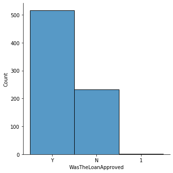

```python
sns.displot(data = dt_train,x = 'WasTheLoanApproved')
```

> - disbalanced classes: use stratified splitting for train/val sets

### b. Distribution and correlation

We apply a quick correlation check by plotting the features against the target variable. A finer analysis could be used to quantify the correlation (T-Test and Chi-Test)

- #### Categorical features

```python
cat_feat = dt.select_dtypes(include=[np.object,np.bool]).columns.tolist()
cat_feat.remove('testSet')
cat_feat.remove('WasTheLoanApproved')
```

```python
data = dt_train.groupby('WasTheLoanApproved')['LoanReason'].value_counts(normalize=True).rename('Count').reset_index()
```

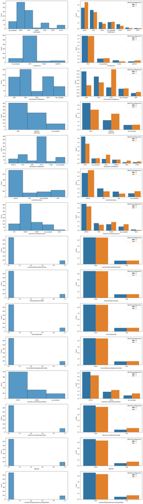

```python
dt_train = dt[dt.testSet == False]
fig,axes = plt.subplots(len(cat_feat),2,figsize = (20,len(cat_feat)*5))
for ax,col in zip(axes,cat_feat):
    sns.histplot(data = dt_train, x = col,ax = ax[0])
    dt_ = dt_train.groupby('WasTheLoanApproved')[col].value_counts(normalize=True).rename('Count').reset_index()
    sns.barplot(data = dt_, x = col,y = 'Count',hue = 'WasTheLoanApproved', ax = ax[1])
```

> - Significant correlated features: LeanReason (goods), CheckingAccountBalance(none, debt,some), DebtsPaid(paid,delayed), SavingAccountbalance(some,none)
- #### Numerical features

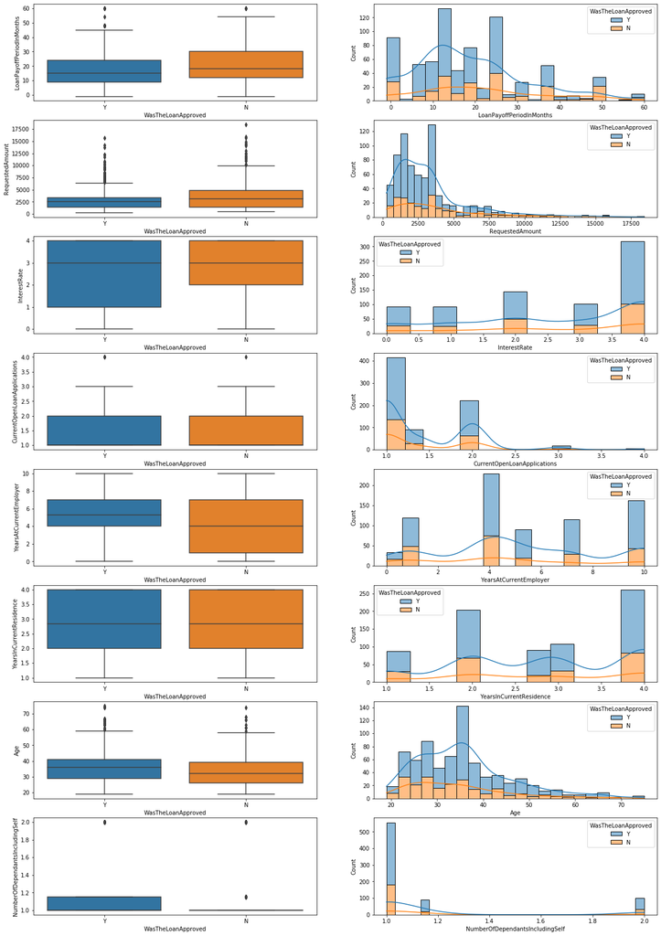

```python
num_col = dt.select_dtypes(np.number).columns.tolist()
dt_train = dt[dt.testSet == False]
fig,axes = plt.subplots(len(num_col),2,figsize = (20,30))
for ax,col in zip(axes,num_col):
    sns.boxplot(data = dt_train, y = col, x = 'WasTheLoanApproved',ax = ax[0])
    sns.histplot(data = dt_train, x = col,hue = 'WasTheLoanApproved', ax = ax[1],multiple='stack')
```

> - Siginifcant correlated features: LoanPayoffPeriodInMonths, RequestedAmount, YearsCurrentEmployer

## 4. Training

### Datasets

Prepare and split dataset for cross-validation:

- .9/.1 split
- Stratified split

```python
# Clean formats
# cast bool into cat
bool_feat = dt.select_dtypes(np.bool).columns
dt[bool_feat] = dt[bool_feat].astype(np.object)
```

```python
#Split
train_set = dt[dt.testSet==False].drop(columns = ['testSet'])
train,test=train_test_split(train_set,train_size = .9,stratify = train_set.WasTheLoanApproved)
x_train,y_train = train.drop(columns = ['WasTheLoanApproved']),train.WasTheLoanApproved
x_test,y_test = test.drop(columns = ['WasTheLoanApproved']),test.WasTheLoanApproved
```

### Pre-processing

```python
# create transformers
ohe = OneHotEncoder(sparse = False)
boxcox = PowerTransformer()
# split features
num_feat = x_train.select_dtypes(np.number).columns
cat_feat = x_train.select_dtypes(np.object).columns.tolist()
# preprocess pipeline
pre_process = ColumnTransformer([('ohe',ohe,cat_feat),('boxcox',boxcox,num_feat)])
```

```python
def remap(x,prefix_map):
    return prefix_map.get(x.split('_')[0])+f'_{"_".join(x.split("_")[1:])}'
def get_ohe_feat_names(pre_process):
    prefix_map = {f'x{c}':i for c,i in enumerate(pre_process.transformers_[0][2])}
    return pd.Series(pre_process.transformers_[0][1].get_feature_names()).map(lambda x: remap(x,prefix_map)).to_list()
def get_feature_names(pre_process):
    result =[]
    for step in pre_process.transformers_:
        if step[0]=='ohe':
            result += get_ohe_feat_names(pre_process)
        else:
            try:
                result += step[1].get_feature_names()
            except:
                result += step[2].tolist()
    return result
```

### Models

#### a. Create models

```python
# Create estimators
dummy = DummyClassifier(strategy = 'stratified')
logit = LogisticRegression(max_iter = 1000)
rdf = RandomForestClassifier()
# Create pipelines
dummy_p = Pipeline(steps = [('preprocess',pre_process),('dummy',dummy)])
logit_p = Pipeline(steps = [('preprocess',pre_process),('logit',logit)])
rdf_p = Pipeline(steps = [('preprocess',pre_process),('rdf',rdf)])
```

#### b.Train

```python
result = []
for pipe in [dummy_p,logit_p,rdf_p]:
    model_name = pipe.steps[1][0]
    pipe.fit(x_train,y_train)
    result += [(model_name,accuracy_score(y_test,pipe.predict(x_test)))]
```

#### c.Evaluation

##### Accuracy

```python
# print result
for a,b in result:
    print(f'Score model {a}: {b}')
```

```
Score model dummy: 0.5466666666666666
Score model logit: 0.7866666666666666
Score model rdf: 0.8
```

##### Confusion matrix

```
<sklearn.metrics._plot.confusion_matrix.ConfusionMatrixDisplay at 0x133c33dd8>
```

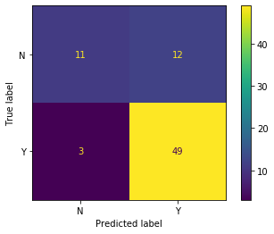

```python
#rdf
plot_confusion_matrix(rdf_p,X = x_test,y_true = y_test)
```

#### d.Feature importance

RDF feature interpretation relies on CART Algorithm and does not indicate how does the features impacts the target var, but how mich it contributes to the tree structure. To draw insights from the trees. Still it gives a good idea of the feature importance.

```python
pre_process.fit(x_train)
rdf_fi = pd.DataFrame(rdf_p.steps[1][1].feature_importances_,index = get_feature_names(pre_process),columns =['feature_importance'])
rdf_fi.sort_values('feature_importance',ascending = False).head(10)
```

|  | feature_importance |
| --- | --- |
| RequestedAmount | 0.135167 |
| Age | 0.107055 |
| LoanPayoffPeriodInMonths | 0.089259 |
| YearsAtCurrentEmployer | 0.059683 |
| InterestRate | 0.047422 |
| CheckingAccountBalance_none | 0.045999 |
| YearsInCurrentResidence | 0.045140 |
| CheckingAccountBalance_debt | 0.034887 |
| CurrentOpenLoanApplications | 0.029844 |
| SavingsAccountBalance_some | 0.027590 |

> - The most important predictors are: RequestedAmount, Age, LoaPayoffPeriodInMonths
> - Interestingly, beside the age, the 2 others stood out in the correlation analysis

To have a better understanding of how one feature impacts the target var, you can fix all the other variables and change the feature you want to interpret. This is the approach below.

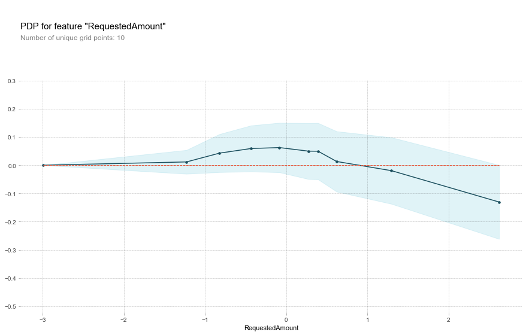

```python
x_train_transf = pre_process.fit_transform(x_train,y_train)
pdp_age = pdp.pdp_isolate(
    model=rdf_p.steps[1][1], dataset=pd.DataFrame(x_train_transf,columns = get_feature_names(pre_process)), model_features=get_feature_names(pre_process), feature='RequestedAmount'
)
# default
fig, axes = pdp.pdp_plot(pdp_age, 'RequestedAmount')
```

> - Between certain values, it increase the likelihood to accept the Loan
> - Under a certain value, it doesnt affect ehe likelihood that the loan is accepted
> - Over a certain value, it decreases the likelihood that the loan is accepted
> - NB: this is normalized data